# FIFA20

AZAD SINGH S

2022-10-18

# Exploratory Analysis of FIFA 20 dataset using R

[figure not shown]

fifa_20 image

With FIFA World Cup 2022 around the corner, I combined my knowledge for football and data analytics to whip up a short exploratory analysis of the FIFA 20 dataset using R. I used the non-physical player attributes such as `short_name, wage_eur, value_eur, age,club, potential, player_positions, Nationality, Overall.`

I used the the `dataset` available on `Kaggle` which contains 17,000+ players featuring in `FIFA20`, each with more than 70 attributes. It is scraped from the website <[SoFIFA](https://sofifa.com/)>.

## SQL part

Before we go to the analysis part first i cleaned the data using `SQL querry in google cloud BigQuerry` [“ab thum log kahoge bigquery woo bhi free mai , aur mai kahunga jalwa hai humara” ] and `took only data of 2000 players` because [“cleaning part mai bhi kuch karna tha na”].

SELECT *

FROM `fifa`

ORDER BY wage_eur DESC

LIMIT 2000

## Importing packages

Before we start the analysis, let’s import the `libraries`.  
#### type this in console

```r
library(tidyverse)
```

```r
 library(skimr)
library(Tmisc)
library(ggplot2)
library(dplyr)
library(gridExtra)
library(tidyselect)
# df = rea
```

## reading file

```r
df = read.csv(file = "table1.csv", stringsAsFactors = FALSE)
df = data.frame(df)
#df <- select_all(df)
```

## Glimpse of Data set

```r
#df <- data_frame(table1)
head(df)
```

```
##   sofifa_id
## 1    158023
## 2    183277
## 3     20801
## 4    194765
## 5    192985
## 6    176580
##                                                              player_url
## 1               https://sofifa.com/player/158023/lionel-messi/20/159586
## 2                https://sofifa.com/player/183277/eden-hazard/20/159586
## 3 https://sofifa.com/player/20801/c-ronaldo-dos-santos-aveiro/20/159586
## 4          https://sofifa.com/player/194765/antoine-griezmann/20/159586
## 5            https://sofifa.com/player/192985/kevin-de-bruyne/20/159586
## 6                https://sofifa.com/player/176580/luis-suarez/20/159586
##          short_name                           long_name age height_cm weight_kg
```

[output cut: 139 more lines]

```r
skim_without_charts(df)
```

Data summary

| Name | df |
| --- | --- |
| Number of rows | 2000 |
| Number of columns | 77 |
| _______________________ |  |
| Column type frequency: |  |
| character | 15 |
| logical | 1 |
| numeric | 61 |
| ________________________ |  |
| Group variables | None |

**Variable type: character**

| skim_variable | n_missing | complete_rate | min | max | empty | n_unique | whitespace |
| --- | --- | --- | --- | --- | --- | --- | --- |
| player_url | 0 | 1 | 49 | 78 | 0 | 2000 | 0 |
| short_name | 0 | 1 | 4 | 21 | 0 | 1983 | 0 |
| long_name | 0 | 1 | 2 | 42 | 0 | 1999 | 0 |
| nationality | 0 | 1 | 4 | 20 | 0 | 94 | 0 |
| club | 0 | 1 | 3 | 30 | 0 | 166 | 0 |
| player_positions | 0 | 1 | 2 | 12 | 0 | 276 | 0 |
| preferred_foot | 0 | 1 | 4 | 5 | 0 | 2 | 0 |
| work_rate | 0 | 1 | 8 | 13 | 0 | 8 | 0 |
| body_type | 0 | 1 | 4 | 19 | 0 | 9 | 0 |
| player_tags | 0 | 1 | 0 | 132 | 1526 | 81 | 0 |
| team_position | 0 | 1 | 2 | 3 | 0 | 29 | 0 |
| loaned_from | 0 | 1 | 0 | 30 | 1913 | 52 | 0 |
| joined | 0 | 1 | 0 | 10 | 87 | 575 | 0 |
| nation_position | 0 | 1 | 0 | 3 | 1523 | 25 | 0 |
| player_traits | 0 | 1 | 0 | 147 | 421 | 531 | 0 |

**Variable type: logical**

| skim_variable | n_missing | complete_rate | mean | count |
| --- | --- | --- | --- | --- |
| real_face | 0 | 1 | 0.55 | TRU: 1095, FAL: 905 |

**Variable type: numeric**

| skim_variable | n_missing | complete_rate | mean | sd | p0 | p25 | p50 | p75 | p100 |
| --- | --- | --- | --- | --- | --- | --- | --- | --- | --- |
| sofifa_id | 0 | 1.00 | 201672.42 | 25503.67 | 1179 | 189168.00 | 203333 | 220044.2 | 251573 |
| age | 0 | 1.00 | 27.25 | 3.70 | 18 | 25.00 | 27 | 30.0 | 41 |
| height_cm | 0 | 1.00 | 182.13 | 6.71 | 163 | 177.00 | 182 | 187.0 | 203 |
| weight_kg | 0 | 1.00 | 76.85 | 7.24 | 56 | 72.00 | 77 | 82.0 | 101 |
| overall | 0 | 1.00 | 77.18 | 4.12 | 66 | 74.00 | 77 | 80.0 | 94 |
| potential | 0 | 1.00 | 79.46 | 4.75 | 68 | 76.00 | 79 | 83.0 | 95 |
| value_eur | 0 | 1.00 | 12309625.00 | 12005200.19 | 525000 | 5500000.00 | 8500000 | 14000000.0 | 105500000 |
| wage_eur | 0 | 1.00 | 50909.50 | 45447.01 | 22000 | 27000.00 | 36000 | 53000.0 | 565000 |
| international_reputation | 0 | 1.00 | 1.66 | 0.79 | 1 | 1.00 | 1 | 2.0 | 5 |
| weak_foot | 0 | 1.00 | 3.20 | 0.72 | 1 | 3.00 | 3 | 4.0 | 5 |
| skill_moves | 0 | 1.00 | 2.92 | 0.88 | 1 | 2.00 | 3 | 3.0 | 5 |
| release_clause_eur | 87 | 0.96 | 23669470.99 | 23545344.26 | 998000 | 9900000.00 | 16200000 | 27700000.0 | 195800000 |
| team_jersey_number | 0 | 1.00 | 16.76 | 13.89 | 1 | 8.00 | 14 | 22.0 | 99 |
| contract_valid_until | 0 | 1.00 | 2021.65 | 1.29 | 2019 | 2021.00 | 2022 | 2023.0 | 2026 |
| nation_jersey_number | 1523 | 0.24 | 11.79 | 6.54 | 1 | 6.00 | 11 | 18.0 | 24 |
| pace | 137 | 0.93 | 70.47 | 11.94 | 29 | 64.00 | 71 | 78.0 | 96 |
| shooting | 137 | 0.93 | 63.57 | 13.63 | 15 | 56.00 | 67 | 73.0 | 93 |
| passing | 137 | 0.93 | 68.47 | 8.86 | 34 | 63.00 | 70 | 75.0 | 92 |
| dribbling | 137 | 0.93 | 72.65 | 8.82 | 34 | 68.00 | 74 | 78.0 | 96 |
| defending | 137 | 0.93 | 59.85 | 18.24 | 18 | 41.50 | 68 | 75.0 | 90 |
| physic | 137 | 0.93 | 71.06 | 8.07 | 41 | 67.00 | 72 | 77.0 | 89 |
| gk_diving | 1863 | 0.07 | 79.07 | 4.68 | 69 | 76.00 | 79 | 82.0 | 90 |
| gk_handling | 1863 | 0.07 | 76.39 | 4.99 | 64 | 73.00 | 76 | 80.0 | 92 |
| gk_kicking | 1863 | 0.07 | 72.72 | 7.42 | 43 | 69.00 | 73 | 78.0 | 93 |
| gk_reflexes | 1863 | 0.07 | 80.83 | 4.84 | 70 | 78.00 | 81 | 84.0 | 92 |
| gk_speed | 1863 | 0.07 | 46.91 | 8.17 | 27 | 42.00 | 48 | 53.0 | 64 |
| gk_positioning | 1863 | 0.07 | 77.84 | 4.88 | 66 | 74.00 | 78 | 81.0 | 91 |
| attacking_crossing | 0 | 1.00 | 61.61 | 18.39 | 7 | 54.00 | 67 | 74.0 | 93 |
| attacking_finishing | 0 | 1.00 | 57.29 | 20.02 | 5 | 44.00 | 63 | 73.0 | 95 |
| attacking_heading_accuracy | 0 | 1.00 | 62.08 | 17.42 | 7 | 55.00 | 66 | 74.0 | 93 |
| attacking_short_passing | 0 | 1.00 | 71.18 | 12.22 | 11 | 68.00 | 74 | 78.0 | 92 |
| attacking_volleys | 0 | 1.00 | 55.44 | 19.15 | 7 | 43.00 | 60 | 70.0 | 90 |
| skill_dribbling | 0 | 1.00 | 68.06 | 17.66 | 7 | 65.00 | 73 | 78.0 | 97 |
| skill_curve | 0 | 1.00 | 60.70 | 19.03 | 9 | 51.75 | 66 | 74.0 | 94 |
| skill_fk_accuracy | 0 | 1.00 | 53.73 | 19.00 | 8 | 40.00 | 57 | 69.0 | 94 |
| skill_long_passing | 0 | 1.00 | 64.91 | 13.34 | 12 | 59.00 | 68 | 74.0 | 92 |
| skill_ball_control | 0 | 1.00 | 71.36 | 14.83 | 9 | 70.00 | 75 | 79.0 | 96 |
| movement_acceleration | 0 | 1.00 | 68.64 | 13.64 | 23 | 61.00 | 70 | 78.0 | 97 |
| movement_sprint_speed | 0 | 1.00 | 69.01 | 13.30 | 24 | 62.00 | 71 | 78.0 | 96 |
| movement_agility | 0 | 1.00 | 68.99 | 13.33 | 23 | 62.00 | 71 | 78.0 | 96 |
| movement_reactions | 0 | 1.00 | 74.43 | 5.82 | 55 | 71.00 | 74 | 78.0 | 96 |
| movement_balance | 0 | 1.00 | 66.68 | 14.18 | 22 | 59.00 | 69 | 77.0 | 96 |
| power_shot_power | 0 | 1.00 | 70.42 | 11.40 | 15 | 65.00 | 73 | 78.0 | 95 |
| power_jumping | 0 | 1.00 | 69.24 | 11.65 | 30 | 64.00 | 71 | 77.0 | 95 |
| power_stamina | 0 | 1.00 | 70.59 | 13.56 | 17 | 66.00 | 73 | 79.0 | 97 |
| power_strength | 0 | 1.00 | 70.56 | 11.15 | 29 | 64.00 | 72 | 78.0 | 95 |
| power_long_shots | 0 | 1.00 | 60.34 | 19.11 | 6 | 54.00 | 67 | 74.0 | 94 |
| mentality_aggression | 0 | 1.00 | 66.68 | 15.94 | 11 | 58.00 | 71 | 78.0 | 94 |
| mentality_interceptions | 0 | 1.00 | 56.75 | 22.11 | 9 | 36.00 | 67 | 76.0 | 92 |
| mentality_positioning | 0 | 1.00 | 62.49 | 19.83 | 5 | 55.00 | 69 | 76.0 | 95 |
| mentality_vision | 0 | 1.00 | 65.81 | 13.19 | 13 | 59.00 | 69 | 75.0 | 94 |
| mentality_penalties | 0 | 1.00 | 57.65 | 16.18 | 9 | 48.00 | 60 | 70.0 | 92 |
| mentality_composure | 0 | 1.00 | 72.28 | 7.94 | 25 | 68.00 | 73 | 78.0 | 96 |
| defending_marking | 0 | 1.00 | 56.51 | 21.42 | 8 | 38.00 | 65 | 74.0 | 94 |
| defending_standing_tackle | 0 | 1.00 | 56.67 | 23.43 | 9 | 35.00 | 68 | 77.0 | 92 |
| defending_sliding_tackle | 0 | 1.00 | 53.41 | 24.00 | 8 | 29.00 | 64 | 74.0 | 90 |
| goalkeeping_diving | 0 | 1.00 | 15.31 | 17.61 | 1 | 8.00 | 11 | 14.0 | 90 |
| goalkeeping_handling | 0 | 1.00 | 15.13 | 16.95 | 1 | 8.00 | 11 | 14.0 | 92 |
| goalkeeping_kicking | 0 | 1.00 | 14.88 | 16.12 | 1 | 8.00 | 11 | 14.0 | 93 |
| goalkeeping_positioning | 0 | 1.00 | 15.22 | 17.32 | 1 | 8.00 | 11 | 14.0 | 91 |
| goalkeeping_reflexes | 0 | 1.00 | 15.35 | 18.09 | 1 | 8.00 | 11 | 14.0 | 92 |

```r
glimpse(df)
```

```
## Rows: 2,000
## Columns: 77
## $ sofifa_id                  <int> 158023, 183277, 20801, 194765, 192985, 1765…
## $ player_url                 <chr> "https://sofifa.com/player/158023/lionel-me…
## $ short_name                 <chr> "L. Messi", "E. Hazard", "Cristiano Ronaldo…
## $ long_name                  <chr> "Lionel Andrés Messi Cuccittini", "Eden Haz…
## $ age                        <int> 32, 28, 34, 28, 28, 32, 33, 29, 31, 30, 33,…
## $ height_cm                  <int> 170, 175, 187, 176, 181, 182, 172, 183, 173…
## $ weight_kg                  <int> 72, 74, 83, 73, 70, 86, 66, 76, 70, 76, 82,…
## $ nationality                <chr> "Argentina", "Belgium", "Portugal", "France…
## $ club                       <chr> "FC Barcelona", "Real Madrid", "Juventus", …
## $ overall                    <int> 94, 91, 93, 89, 91, 89, 90, 88, 89, 89, 89,…
## $ potential                  <int> 94, 91, 93, 89, 91, 89, 90, 88, 89, 89, 89,…
## $ value_eur                  <int> 95500000, 90000000, 58500000, 69000000, 900…
## $ wage_eur                   <int> 565000, 470000, 405000, 370000, 370000, 355…
```

[output cut: 64 more lines]

## Ploting the graphs

Then after assignment process ,I started plotting graph as the initial phase using ggplot function of the `tidyverse package.`

firstly I brought the bar chart using ggplot which shows the count of `players_potential` that signifies the players potential which has the highest count of players.

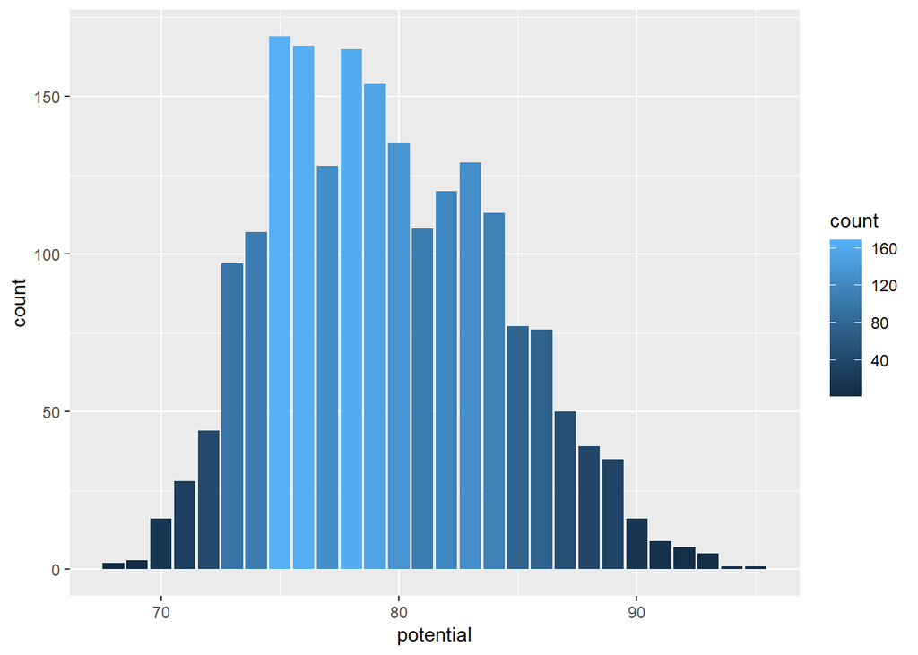

```r
ggplot(data = df) +
  geom_bar(mapping = aes(x = potential, fill = ..count.. ))
```

```r
ggtitle("Potential distribution chart")
```

```
## $title
## [1] "Potential distribution chart"
##
## attr(,"class")
## [1] "labels"
```

then I used a variable to generate the table `'tt'` of top en richest players of football with high potential and which was by default the first 10 rows as I already used the `SQL querry` to sort data in the descending order which by default made the top paid players on the top and the data was extracted from the data frame.

```r
tt <- head(df,10) %>% select(short_name, wage_eur, value_eur, age,club, potential, player_positions)
head(tt)
```

```
##          short_name wage_eur value_eur age            club potential
## 1          L. Messi   565000  95500000  32    FC Barcelona        94
## 2         E. Hazard   470000  90000000  28     Real Madrid        91
## 3 Cristiano Ronaldo   405000  58500000  34        Juventus        93
## 4      A. Griezmann   370000  69000000  28    FC Barcelona        89
## 5      K. De Bruyne   370000  90000000  28 Manchester City        91
## 6         L. Suárez   355000  53000000  32    FC Barcelona        89
##   player_positions
## 1       RW, CF, ST
## 2           LW, CF
## 3           ST, LW
## 4       CF, ST, LW
## 5          CAM, CM
## 6               ST
```

[figure not shown]

then I plotted the same kind of graph that is bar graph using the attribute Age .

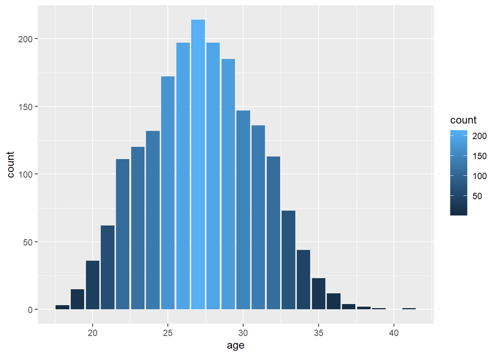

```r
ggplot(data = df) +
 geom_bar(mapping = aes(x =age, fill = ..count.. ))
```

```r
ggtitle("Age distribution chart")
```

```
## $title
## [1] "Age distribution chart"
##
## attr(,"class")
## [1] "labels"
```

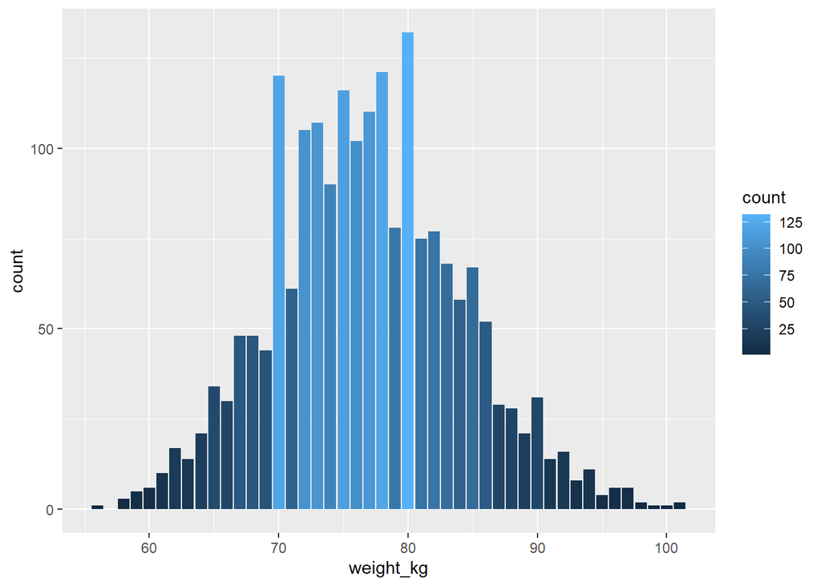

```r
ggplot(data = df) +
  geom_bar(mapping = aes(x = weight_kg, fill = ..count.. ))
```

```r
ggtitle("weight distribution chart")
```

```
## $title
## [1] "weight distribution chart"
##
## attr(,"class")
## [1] "labels"
```

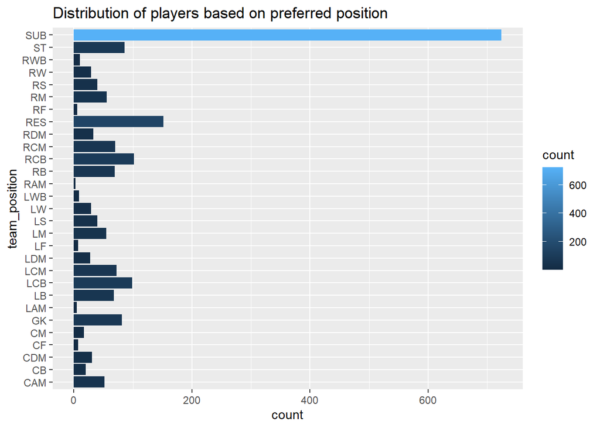

```r
ggplot(data = df) +
  geom_bar(mapping = aes(y = team_position , fill = ..count..)) +
  ggtitle("Distribution of players based on preferred position")
```

then i worked on to differentiate that what was the foot which majority if the players used anf clearly found that majority of players used right foot here I also used attributes potential to differentiate which foot performed better.

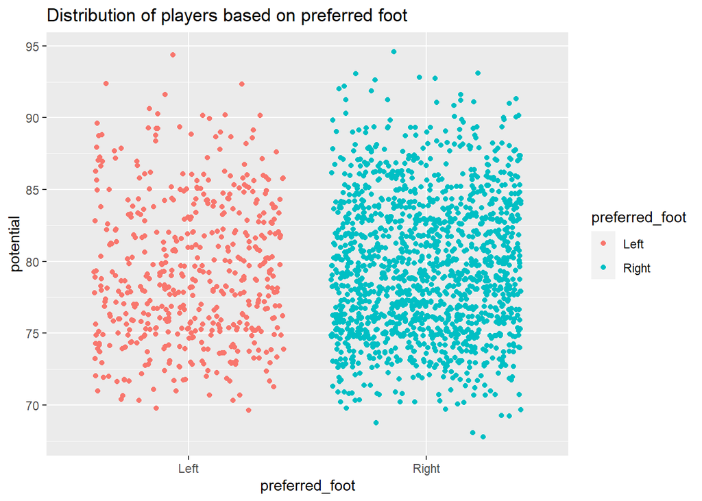

```r
ggplot(data = df ,aes(x = preferred_foot, y = potential, color = preferred_foot)) +
  geom_jitter() +ggtitle("Distribution of players based on preferred foot")
```

so first I will install grid package

#### Type this in console

install.packages(“ggplot2”) library(ggplot2)

install.packages(“gridExtra”) library(gridExtra)

now the code,

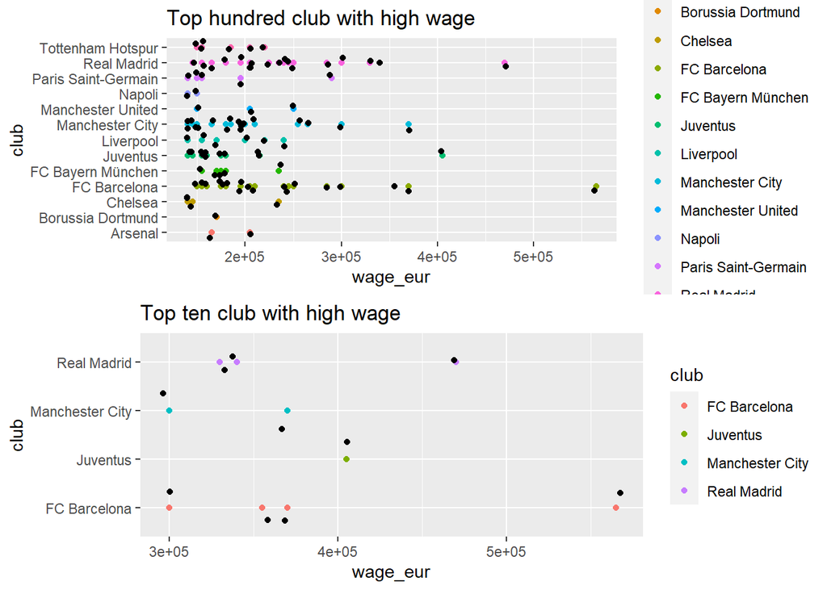

```r
mm <- head(df,100) %>% select(short_name, wage_eur, value_eur, age,club, potential, player_positions, )
pp <- head(df,10) %>% select(short_name, wage_eur, value_eur, age,club, potential, player_positions, )

p1 <- ggplot(data = mm ,aes(y = club, x = wage_eur))
g1 <- p1 +  geom_point(aes(color= club)) + geom_jitter() + ggtitle("Top hundred club with high wage")
  p2 <- ggplot(data = pp ,aes(y = club, x = wage_eur))
g2 <- p2 + geom_point(aes(color= club)) + geom_jitter() + ggtitle("Top ten club with high wage")
grid.arrange(g1, g2, ncol=1)
```

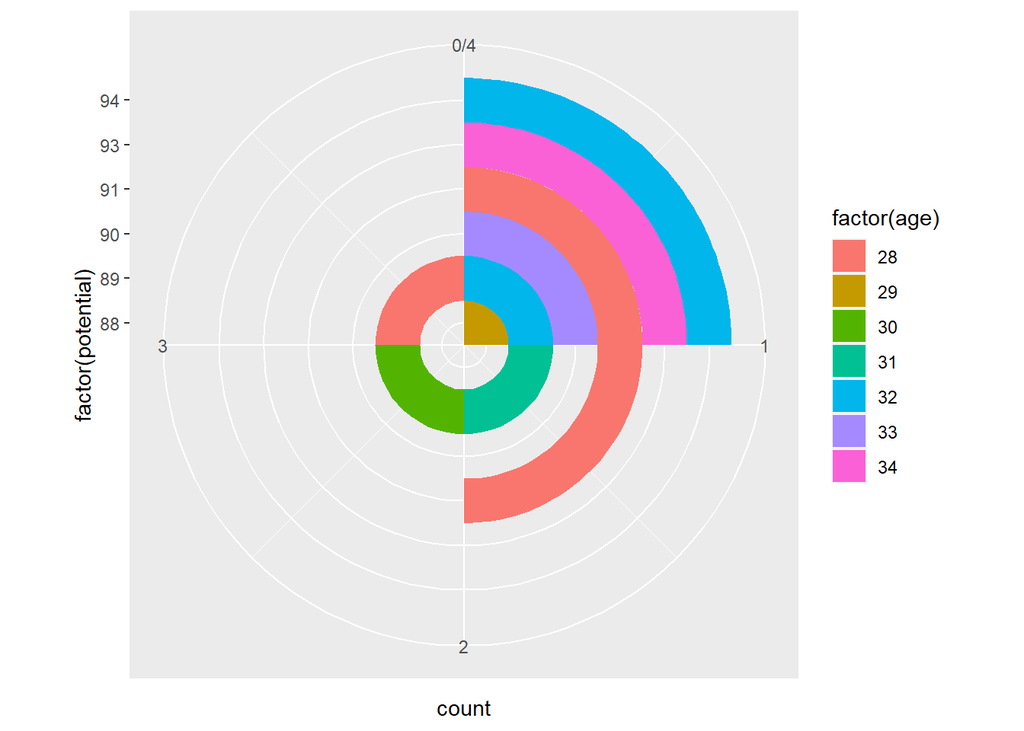

```r
tal <- head(df,10) %>% select(short_name, wage_eur, value_eur, age,club, potential, player_positions, )


ggplot(data = tal, aes(x = factor(potential), fill = factor(age))) +
  geom_bar(width = 1) + coord_polar(theta = "y")
```

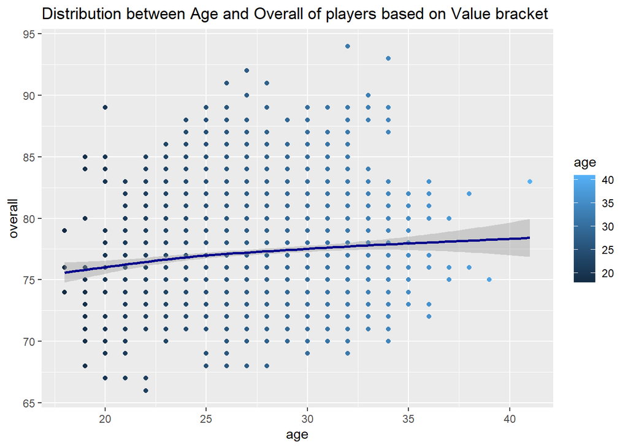

```r
g_age_overall <- ggplot(df, aes(age, overall))
g_age_overall + geom_point(aes(color = age)) + geom_smooth(color="darkblue") +
  ggtitle("Distribution between Age and Overall of players based on Value bracket")
```

I bought few data through tableau also so that i can make it more understandable to the viewer by following 5 second rule.

## Tablue generated maps and graphs

### Average age of countries all over in football

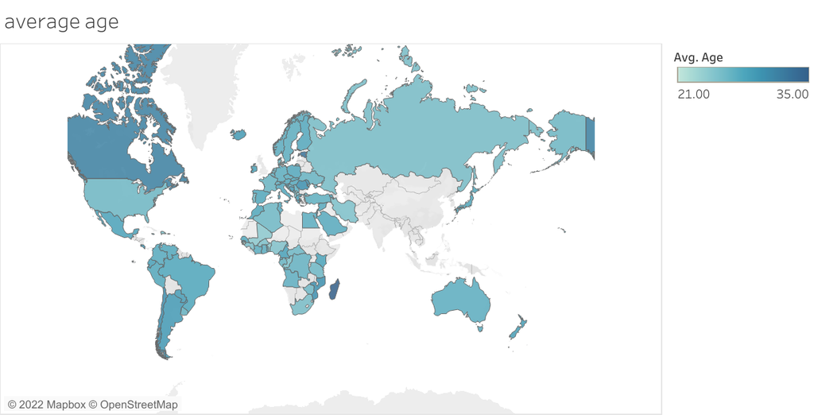

[figure not shown]

Thank you for reading. You can find the source code(R-notebook) at RPubs and GitHub. You can find me on <[LinkedIn](https://www.linkedin.com/in/azad-singh-s-97a2a4225/)> , <[Twitter](https://twitter.com/Azad4people)> ,<[gitlab](https://gitlab.com/AZADSINGHS)> and <[Github](https://github.com/AZAD7337889873)>.

```r
#getwd()
#list.files("C:/path2/r.jpg", full.names=TRUE)
```